## Group Prime Stat 133 Final Presentation

Vaibhav Ramamoorthy, Namrata Das, Jonathan Xu, Salil Vanvari

### Key Question

When users look at reviews, what types of reviews do they find helpful? How do things like the score rating of a review, word length of review, or specific words within the review affect a review’s helpfulness?

### Dataset Used

We set out to find this by analyzing the [Amazon Food Reviews](https://www.kaggle.com/snap/amazon-fine-food-reviews) dataset, provided by Kaggle. Apart from `Id`, `UserId`, `dateTime`, and `ProfileName`, we used all the variables in our analysis.  
Here’s the structure of the dataset we worked with:

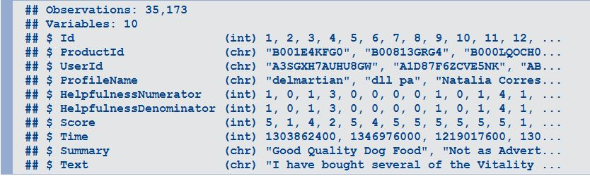

### Method

Data wrangling with `dplyr`, data visualization with `ggplot2`. External packages `stringi` and `data.table`. External `foodwords` data set.

### We looked at some more detailed questions to analyze our key question and graphed our results

#### Does the length of the review affect helpfulness?

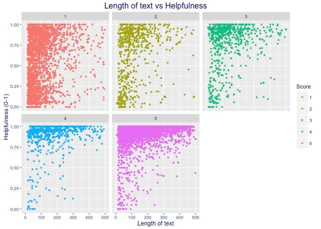

#### Are the most helpful reviews that ones that received the most votes (whether it was upvoted or downvoted)

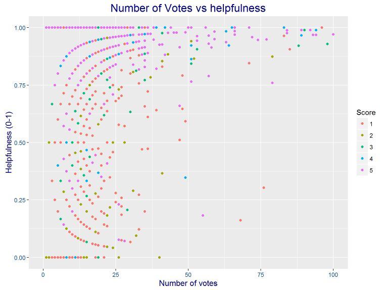

### More analyses and our conclusion

#### Do people prefer to read higher rated reviews (thus finding them more helpful?)

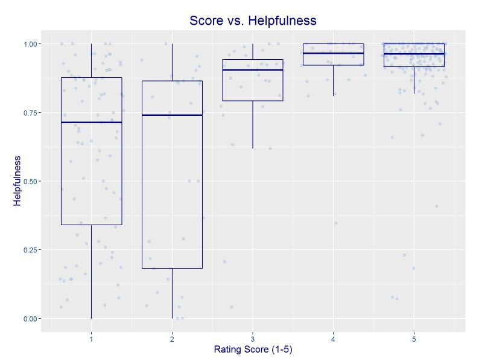

#### What food adjectives are used in most helpful reviews?

[Food adjectives used in conjunction to create this graph](https://foxhugh.com/word-lists/list-of-food-adjectives/)

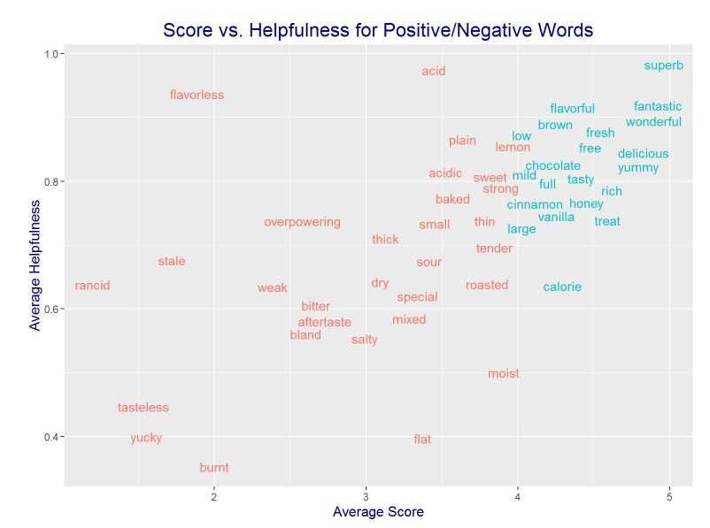

### Conclusion

The most helpful reviews are influenced by many different variables; however, we see the strongest correlation with high ratings. Positive food adjectives and length of the reviews also affect (to a lesser extent) if the review is deemed helpful or not.